# Session 1b

Peter Prevos

31 January 2022

## Learning Objectives Part 1

- Apply the principles of strategic data science to solve water problems
- Write R code to load, analyse, and visualise data
- Diagnose water quality data with descriptive statistics
- Develop presentations, reports, and applications to share results

## Program Session 1b

1. Summary first session and coding practice
2. Principles of visualisation
3. Visualise data with ggplot2
4. Data science workflow
5. Creating data products

# Summary Session 1a

## Coding Excercise

- Go to the Bureau of Meteorology website
  - http://www.bom.gov.au/climate/data/stations/
- Download rainfall data and for your nearest station
- Determine the top five years with the highest total rainfall
- Tips:
  - Variable names with spaces need to be between back ticks: ``variable name``
  - The data has missing values. Use the `na.rm = TRUE` option in the `sum()` function
  - Use the `top_n()` function to list the top five years

## Solution

```r
library(tidyverse)
bom <- read_csv("casestudy1/IDCJAC0009_088110_1800_Data.csv")
bom_year <- group_by(filter(bom, Year != 2022), Year)
annual_rain <- summarise(bom_year,
                         TotalRain = sum(`Rainfall amount (millimetres)`,
                                         na.rm = TRUE))
top_n(annual_rain, 5)
```

```
## # A tibble: 5 × 2
##    Year TotalRain
##   <dbl>     <dbl>
## 1  1973      970
## 2  1974      796
## 3  1993      802.
## 4  2010      962.
## 5  2011      830.
```

# Visualising Data

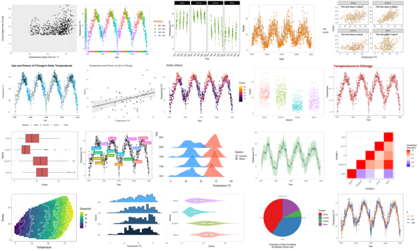

## Jackson Pollock

[figure not shown]

Jackson Pollock (1952) Blue Poles number 11. Drip Painting in enamel and aluminium paint with glass on canvas (National Gallery, Canberra).

## Piet Mondrian

[figure not shown]

Piet Mondrian (1928) Composition with red, yellow and blue. Oil on canvas (Municipal Museum, the Hague).

## Data-Pixel Ratio

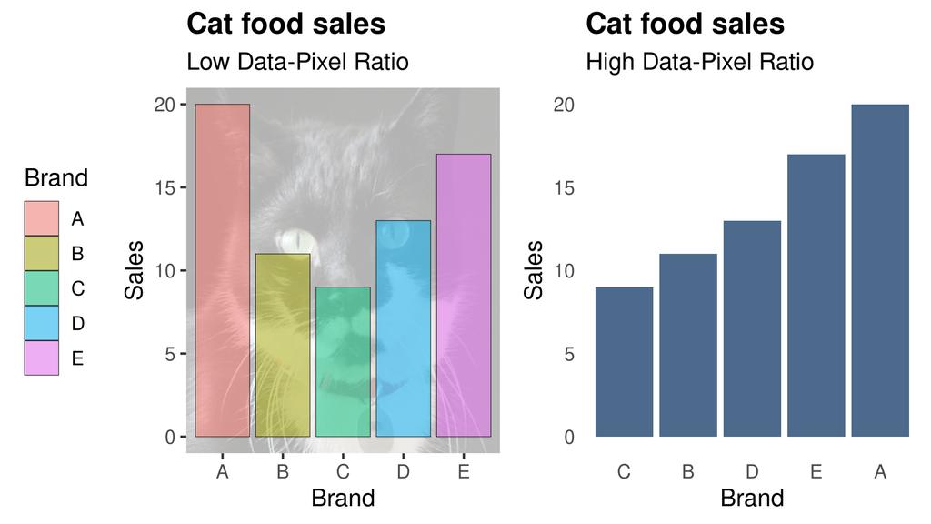

## Data Story-Telling

[figure not shown]

## Grammar of Graphics

1. *Data*: exists at the lowest level, without which there is nothing to visualise.
2. *Aesthetics*: defines which graph variables are visualised and how they look (colour, line shapes and sizes).
3. *Geometries*: shapes that represent the data, such as bars, pies or lines.
4. *Facets*: used to divide a visualisation into subplots.
5. *Statistics*: relate to any specific transformations to summarise the data, such as trend lines.
6. *Coordinates*: define how data is represented on the canvas. Mostly used in mapping.
7. *Themes*: defines the non-data pixels (font sizes, backgrounds and so on)

# Base Plots

- Best for exploratory visualisations
- Plotting functions
  - `plot()`
  - `barplot()`
  - `histogram()`
  - `boxplot()`
- Annotation functions (add elements to the plot)

## Base plotting parameters

- `pch`: the plotting symbol (default is open circle)
- `lty`: the line type (default is solid line), can be dashed, dotted, etc.
- `lwd`: the line width, specified as an integer multiple
- `col`: the plotting color, specified as a number, string, or hex code
- `xlab`: character string for the x-axis label
- `ylab`: character string for the y-axis label

## Examples

```r
library(tidyverse)
gormsey <- read_csv("casestudy1/gormsey.csv")
turbidity <- filter(gormsey, Measure == "Turbidity")

plot(turbidity$Date, turbidity$Result,
     type = "l",
     xlab = "Date",
     ylab = "Result",
     main = "Turbidity measurements")
abline(h = 5, col = "red")

boxplot(log10(Result) ~ Town, data = turbidity,
        pch = 19, las = 3, col = "brown",
        main = "Turbidity measurements")
abline(h = log10(5), col = "red")

p95 <- summarise(group_by(turbidity, Town),
                 p95 = quantile(Result, 0.95))

barplot(p95$p95, names.arg = p95$Town)
abline(h = 5, col = "red")
```

# ggplot2 package

## Examples 1

```r
ggplot(gormsey, aes(Town))

ggplot(gormsey, aes(Measure)) +
    geom_bar()

turbidity <- filter(gormsey, Measure == "Turbidity")

ggplot(turbidity, aes(Date, Result, col = Town)) +
    geom_line()
```

## Color Palettes

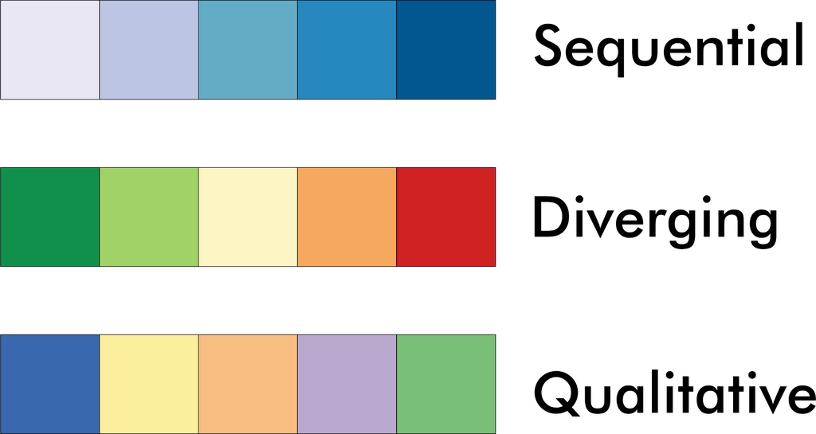

## ColorBrewer

```r
ggplot(gormsey, aes(Town, fill = Measure)) +
    geom_bar() +
    scale_fill_brewer(type = "qual",
                      palette = "Dark2")

library(RColorBrewer)
display.brewer.all()

ggplot(gormsey, aes(Town, fill = Measure)) +
    geom_bar() +
    scale_fill_manual(values = c("cornflowerblue",
                                 "darkseagreen",
                                 "#ee6611",
                                 "#ccaa44"))
```

## Facets

```r
ggplot(turbidity, aes(Date, Result, col = Town)) +
    geom_line() +
    facet_wrap(~Town)
```

## Statistics

```r
thm <- filter(gormsey, Measure == "THM")
thm_grouped <- group_by(thm, Date)
thm_max <- summarise(thm_grouped, thm_max = max(Result))

ggplot(thm_max, aes(Date, thm_max)) +
    geom_smooth(method = "lm") +
    geom_line() +
    geom_hline(yintercept = 0.25, col = "red")
```

Practice Task: Convert this visualisation to a faceted graph to show the trend per system.

## Coordinates

```r
ggplot(turbidity, aes(Town, Result)) +
    geom_boxplot() +
    scale_y_log10(name = "Samples (log)",
                  n.breaks = 10) +
    coord_flip()
```

- `scale_x_log10()`: Logarithmic scale.
- `scale_x_discrete()`: Discrete variables (names).
- `scale_x_continuous()`: Continuous variables, such as measurements.
- `scale_x_date()`: For displaying dates and times.

## Themes

```r
ggplot(turbidity, aes(Date, Result)) +
    geom_area(col = "dodgerblue", fill = "dodgerblue") +
    facet_wrap(~Town, ncol = 1) +
    theme_void(base_size = 24)

ggplot(gormsey, aes(Measure)) +
    geom_bar() +
    theme(axis.text.x = element_text(angle = 90))

ggsave("casestudy1/measures.png", width = 15, height = 10, dpi = 300, units = "cm")
```

## ggplo2 Cheat Sheet

https://raw.githubusercontent.com/rstudio/cheatsheets/master/data-visualization-2.1.pdf

# Data Science Workflow

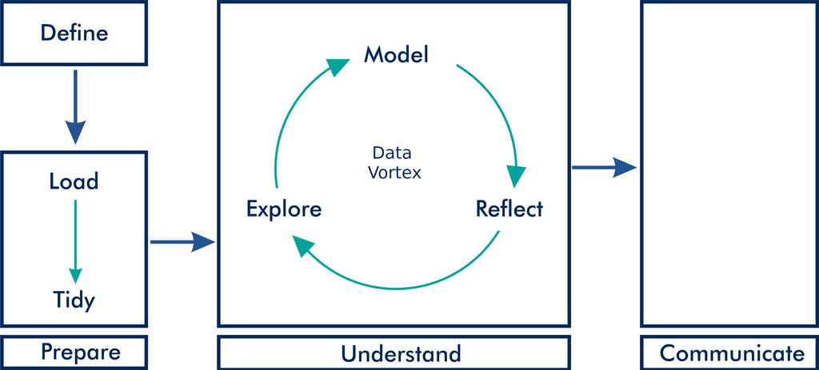

## Define

> The regulator for water quality has released a new guideline that lowers the maximum value for trihalomethanes (THMs) at the customer tap to 0.20 mg/l. This report assesses the historical performance of the Gormsey water system to evaluate the risk of non-compliance, assuming no operational changes are implemented.

## Load and Tidy

```r
library(readr)
library(dplyr)
gormsey <- read_csv("casestudy1/gormsey.csv")
thm <- filter(gormsey, Measure == "THM")
glimpse(thm)
```

```
## Rows: 168
## Columns: 7
## $ Sample_No    <dbl> 608188, 618273, 620904, 629974, 623529, 638727, 659889, 6…
## $ Date         <date> 2069-01-11, 2069-01-16, 2069-01-16, 2069-01-23, 2069-01-…
## $ Sample_Point <chr> "BL_15694", "SO_12411", "SW_17608", "TA_16763", "ME_15385…
## $ Town         <chr> "Blancathey", "Southwold", "Swadlincote", "Tarnstead", "M…
## $ Measure      <chr> "THM", "THM", "THM", "THM", "THM", "THM", "THM", "THM", "…
## $ Result       <dbl> 0.00300, 0.00300, 0.02100, 0.00300, 0.02600, 0.00300, 0.0…
## $ Units        <chr> "mg/L", "mg/L", "mg/L", "mg/L", "mg/L", "mg/L", "mg/L", "…
```

## Explore

## Model

## Reflect

## Communicate

### Tables

```r
library(knitr)
thm_fail <- filter(gormsey, Measure == "THM" & Result > .25)
kable(select(thm_fail, Date, Town, Result),
      caption = "Example outut of the `kable()` function.",
      digits = 2)
```

Example outut of the `kable()` function.

| Date | Town | Result |
| --- | --- | --- |
| 2069-02-06 | Merton | 0.76 |
| 2070-03-26 | Southwold | 0.48 |
| 2070-06-12 | Merton | 0.36 |
| 2070-08-06 | Merton | 0.27 |
| 2070-12-10 | Merton | 0.71 |

## Communicate

### Rounding Numbers

```r
a <- sqrt(777)
round(a)
```

```
## [1] 28
```

```r
round(a, 2)
```

```
## [1] 27.87
```

```r
round(a, -1)
```

```
## [1] 30
```

```r
floor(a)
```

```
## [1] 27
```

```r
ceiling(a)
```

```
## [1] 28
```

```r
signif(a, 5)
```

```
## [1] 27.875
```